# Tarea 1 - Semestre Otoño 2021

Nicolás Acevedo, Constanza Bastías, Pablo Ubilla

12 de mayo de 2021

**Universidad de Chile**

**Ingeniería Industrial**

**IN5602**: Marketing II

**Prof**: Marcel Goic

**Auxs**: R. Cerda, JP. Coddou, G.Mora, F. Moraga, A .Muñoz

## Enunciado

El canal moderno de supermercados ha crecido sostenidamente en todo el mundo y especialmente en los países en desarrollo. En esta tarea exploraremos el comportamiento de compras en una cadena de supermercados en Asia. Para estos efectos, “Supermerca2” ha provisto con información de ventas para tres de sus sucursales (A), (B) y (C) las cuales tienen sedes en las ciudades de Yangon, Mandalay y Naypyidaw respectivamente, en el lejano país de Birmania. “Supermerca2” vende productos de todo tipo, desde accesorios de moda hasta artículos de hogar y estilo de vida. Adicionalmente, la cadena posee un club de lealtad en que los clientes frecuentes pueden registrar sus compras al momento de la compra y así acceder a beneficios posteriormente.

Entre otras preguntas, “Supermerca2” está interesado en entender la satisfacción de sus clientes y así poder decidir sobre qué clientes enfocar los esfuerzos de ventas. En particular, en esta tarea nos concentraremos en entender qué factores afectan el Rating de un cliente, que corresponde a un puntaje en una escala de 10 puntos que indica el grado de satisfacción en la experiencia de compra. El estudio de la satisfacción de los clientes es relevante ya que por un lado nos permite identificar si ciertas salas del supermercado podrían estar entregando un servicio insatisfactorio y por otro nos entrega una señal temprana para saber la probabilidad de que un cliente haga una compra a futuro. En este sentido, la evaluación de la calidad de servicio podría ser informativa respecto al comportamiento de compra futuro.

Para el análisis dispone de una base de datos con una muestra de 1000 compras. El conjunto de datos es uno de los históricos de ventas de la empresa en donde se han registrado IDs de diferentes facturas en sus 3 sucursales durante las horas del día en que atienden. Además, se tienen registros del género del cliente, el precio y la cantidad del producto comprado, la forma de pago, entre otras.

La base de datos está disponible en https://www.kaggle.com/aungpyaeap/supermarket-sales, donde además puede acceder a un diccionario de datos con una descripción de cada una de las variables disponibles en la base de datos.

#### **Preguntas**

1. (0 puntos) Explore los datos para entender la satisfacción de los clientes y qué variables podrían ayudar a predecir cuando un cliente está más satisfecho.
2. (2.0 puntos) Usando los aprendizajes derivados de la exploración de datos, use un enfoque de regresión lineal para examinar cuantitativamente qué factores determinan la satisfacción al momento de realizar una compra.
- 1. Proponga al menos dos especificaciones alternativas para el objetivo propuesto. Justifique muy brevemente por que las variables que está incluyendo en el modelo tienen sentido desde el punto de vista del negocio. Justifique además el nivel de agregación escogido y los índices considerados en el modelo.
- 2. Sobre los dos modelos planteados en la parte anterior, aplique un método de selección automática de variables y compare respecto a los resultados anteriores.
3. (1.0 puntos) Use al menos dos de los modelos de aprendizaje de máquinas que vimos en clases (MARS, kNN, regression tree, random forest) para generar un pronóstico de Rating de un cliente al realizar una compra y compare la capacidad de estos modelos con respecto a los de regresión lineal.
4. (0.5 puntos) Compare las fortalezas y debilidades de los modelos anteriores, evalúe de acuerdo a algunas de las métricas que vimos en clases y discuta qué modelo recomendaría usar.
5. (2.0 puntos) En esta parte, se compararán los grados de satisfacción entre las distintas salas de la cadena de supermercados. Para lo siguiente usted deberá clasificar cada evaluación de la calidad de servicios de acuerdo a si el cliente está o no satisfecho. Para eso puede considerar que un cliente está satisfecho si tiene un Rating mayor o igual a los 7 puntos. Con esto:
- 1. Estimar un modelo de decisión homogéneo para cada sucursal y compare sus resultados entre sucursales. Discuta brevemente sus resultados.
- 2. Estimar un modelo de decisión heterogéneo para cada sucursal y compare sus resultados entre sucursales. Discuta brevemente sus resultados.
- *Observación: Recuerde que la variable utilizada es entera.*
6. (0.5 puntos) Resuma sus aprendizajes principales en un máximo de 4 tablas o figuras. Redacte de manera concisa sus resultados tal como los reportaría al departamento comercial interesado en aprender del comportamiento de clientes. Agregue cualquier conclusión o idea que le parezca relevante de comunicar.

#### **Reglas del juego**

- Las tareas buscan replicar parcialmente las labores a las que se enfrentarían en el análisis de datos en una organización para el apoyo en la toma de decisiones. Por esto, se han propuesto preguntas relativamente abiertas que requieren que ustedes discutan y decidan cual es el mejor enfoque de solución. Les pedimos que se involucren tempranamente en el desarrollo de la tarea para tener una discusión enriquecedora.
- Todas las dudas, comentarios y errores publicarlos exclusivamente en el foro de u-cursos. De esta forma todos se benefician de las respuestas ofrecidas.
- Consideramos que es muy importante que logren escribir un informe conciso con una redacción acorde de un informe técnico profesional, los análisis y las conclusiones que obtengan de cada pregunta es en específico lo que debe declararse. La presentación y comunicación de resultados es parte integral de la tarea y por tanto será evaluada cuidadosamente.
- La tarea se desarrolla en grupos de máximo 3 integrantes. No hay excepciones. El entregable principal es un único markdown separado en tres tabs (a través de la opción .tabset). En el primer tab incluya todo el desarrollo de la tarea adecuadamente comentado. El segundo tab incluya el resumen de sus resultado de acuerdo a lo pedido en la pregunta 6. Este segundo tab es el que usarán en caso de que les corresponda presentar sus resultados. Considere el tercer tab como de anexos y puede incluir aquí cualquier resultado complementario. Para entregar sus resultados suba vía u-cursos un único archivo comprimido llamado t1-A1-A2-A3.zip, donde A1, A2 y A3 es el primer apellido de los integrantes del grupo. Incluya tanto el archivo .html de salida del markdown como los códigos fuentes que permitan reproducir sus resultados.
- Para la pregunta 6 consideramos que 4 figuras son suficientes para resumir los aprendizajes más relevantes, pero si están convencidos de que agregar una figura adicional es absolutamente necesaria, ¡adelante!
- La fecha de entrega de la tarea es el día miércoles 5 de Mayo a las 09:00 hrs, sin excepciones y no habrá plazo extra para la entrega. Si por algún motivo de fuerza mayor se ve imposibilitado de entregar la tarea en el plazo estipulado, deberá escribir directamente al profesor explicando su situación. El profesor decidirá el curso de acción de acuerdo a los méritos del caso.
- Recuerde que tenemos contempladas dos sesiones de presentaciones de las tareas. La primera sesión, a realizarse el día jueves 29 de Abril, está destinada a que compartan sus avances y podamos identificar de manera conjunta cuáles podrían ser dificultades técnicas que requieran orientación adicional. La segunda sesión, a realizarse el día jueves 6 de Mayo, está destinada para que expongan los resultados más relevantes de su trabajo y resuman sus principales aprendizajes, para que tanto los compañeros como el equipo docente puedan proveer retroalimentación. Todos los grupos deben estar disponibles para presentar en ambas ocasiones, pero si hay grupos voluntarios se les dará preferencia. Las presentaciones tendrán una duración máxima de 10 minutos y no es necesario que preparen material adicional. Esperamos que la salida del markdown sea lo suficientemente explicativa para comunicar sus resultados.
- El equipo docente considera que la copia de tareas atenta en contra de tu aprendizaje y por tanto aplicará todas las medidas que estén a su disposición para desincentivar esta mala práctica.

## Preliminares

Escribe acá todos los comandos que necesitas ejecutar antes de abordar las preguntas de la tarea (carga de librerías, lectura de datos, limpieza de la data, transformación de variables y todo lo que necesites)

#### Preparación Tarea

1. Se cargan las librerías a utilizar, y se prepara el ambiente de R
2. Se transformar las variables necesarias
3. Se divide la base de datos en entrenamiento (train) y testeo (test) utilizando 80/20%

## Desarrollo

Documenta acá el desarrollo de tu tarea por pregunta.

#### Pregunta 1

(0 puntos) Explore los datos para entender la satisfacción de los clientes y qué variables podrían ayudar a predecir cuando un cliente está más satisfecho.

A continuación se realizan distitnos EDA, el primero sólo viendo cómo se comportan los datos de la base de datos (df), el segundo (bidimensional) se ve la relación entre las variables dadas , y los siguientes interaccionando variables, o bien con las creadas en la parte anterior.

##### 1. Exploración de datos

En primera instancia, se debe notar que hay ciertas variables en la base de datos que son redundantes o que no aportan nada de información en cuanto a la variabilidad de la variable de interés, como lo es caso de:

- `City`: Aporta la misma información que `Branch`, por lo que es redundante (sólo 1 tienda por ciudad).
- `Gross margin percentage`: Se mantiene constante también en toda la base.
- `Total`: Se define como `Unit price`*`Quantity`(1+0.05) = `Total`, por lo que es es reduante una vez que tenemos la información de las otras dos (sin tomar en cuenta la que es constante, ya que es sólo un ponderador fijo).
- `Cogs`: Se define casi de manera idéntica a `Total`, ya que tiene los mismos valores que `Unit price`*`Quantity`, por lo que también es redundante.
- `Tax`: Es una proporción (5%) de las variables de precio y cantidad nuevamente, por lo que es redundante.
- `Gross income`: Es idéntico a `Tax`; es reduntante.

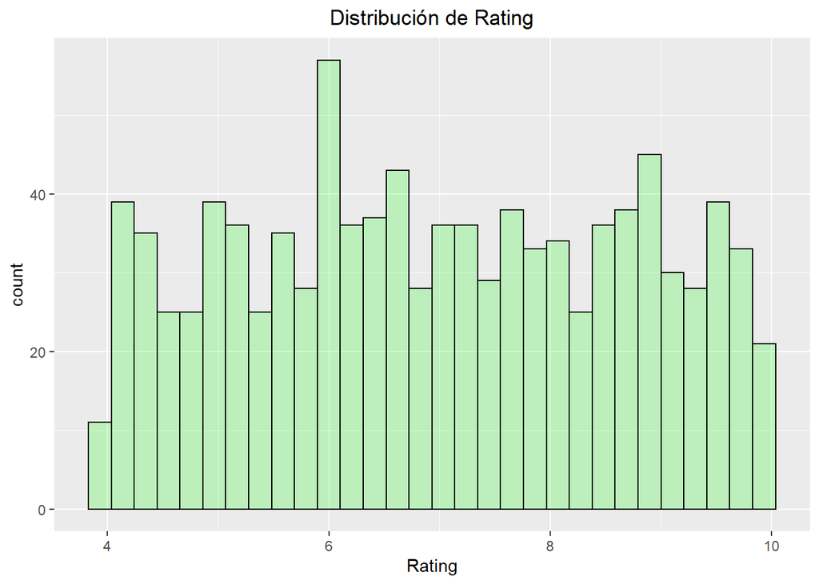

```r
#Exploración de datos

#1. Histograma variable de interes
ggplot(data=df)+ #Se define un gráfico con ggplot()
  aes(x=Rating)+ #Solo le ingresamos el eje "x" para un histograma
  geom_histogram(col="black", fill="green", alpha = 0.2)+ # Se define la forma del gráfico. "col" pinta el contorno, "fill" el entorno y "alpha" entrega transparencia
  ggtitle("Distribución de Rating") +#Título del gráfico
  theme(plot.title = element_text(hjust = 0.5))
```

[figure not shown]

```r
#2. Histograma Unit price
ggplot(data=df)+
  aes(x=Total)+
  geom_histogram(col="black", fill="green", alpha=0.2)+
  xlab("Precio unitario")+ #Etiqueta para el eje x
  ylab("Frecuencia")+ #Etiqueta para el eje y
  ggtitle("Distribución Precio unitario")+ #Título del gráfico
  theme(plot.title = element_text(hjust = 0.5)) #centra el título en el gráfico. Lo ajusta en la posición horizontal (hjust = 0.5)
```

[figure not shown]

```r
#3. Histograma Unit price usando log()
ggplot(data=df)+
  aes(x=log(Total))+
  geom_histogram(col="black", fill="green", alpha=0.2)+
  xlab("log(Precio unitario)")+ #Etiqueta para el eje x
  ylab("Frecuencia")+ #Etiqueta para el eje y
  ggtitle("Distribución Precio unitario Logarítmico")+ #Título del gráfico
  theme(plot.title = element_text(hjust = 0.5)) #centra el título en el gráfico. Lo ajusta en la posición horizontal (hjust = 0.5)
```

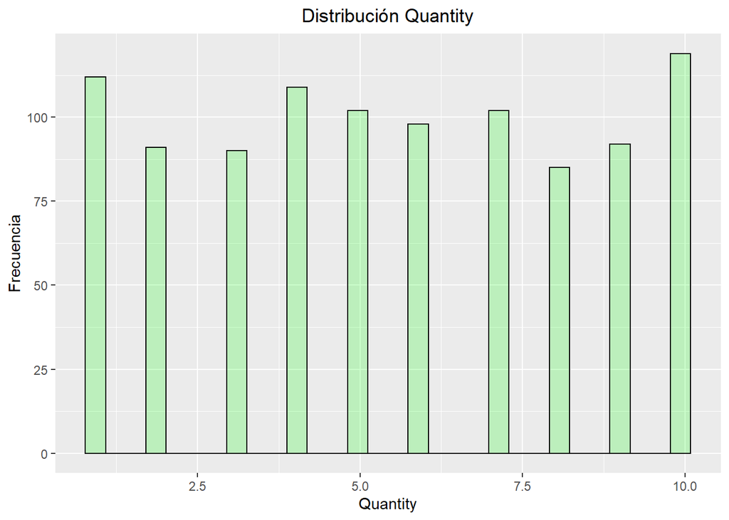

```r
#4. Histograma de Quantity
ggplot(data=df)+
  aes(x=Quantity)+
  geom_histogram(col="black", fill="green", alpha=0.2)+
  xlab("Quantity")+ #Etiqueta para el eje x
  ylab("Frecuencia")+ #Etiqueta para el eje y
  ggtitle("Distribución Quantity")+ #Título del gráfico
  theme(plot.title = element_text(hjust = 0.5)) #centra el título en el gráfico. Lo ajusta en la posición horizontal (hjust = 0.5)
```

Se ve que no existe ninguna relación aparente entre las distribuciones de estas variables numéricas. Sin embargo, relaciones entre ellas o con otros atributos podrían tener incidencia en la variable de interés, por lo que no se van a obviar en primera instancia.

##### 2. EDA BIDEMSIONAL

Ahora se analizarán los efectos de las variables independientes de maner gráfica, con sólo una variable explicativa por plot. El análisis a continuación sólo se hará con las variables categóricas:

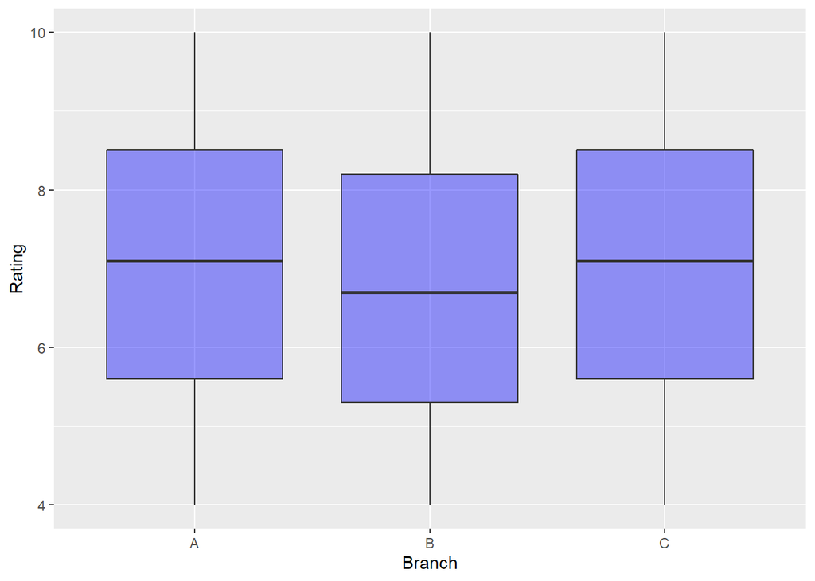

```r
#5. Boxplot Branch vs Rating
ggplot(df) +
  aes(x=Branch, y=Rating) +
  geom_boxplot(alpha=0.4, fill="blue") #cambiamos el tipo de gráfico
```

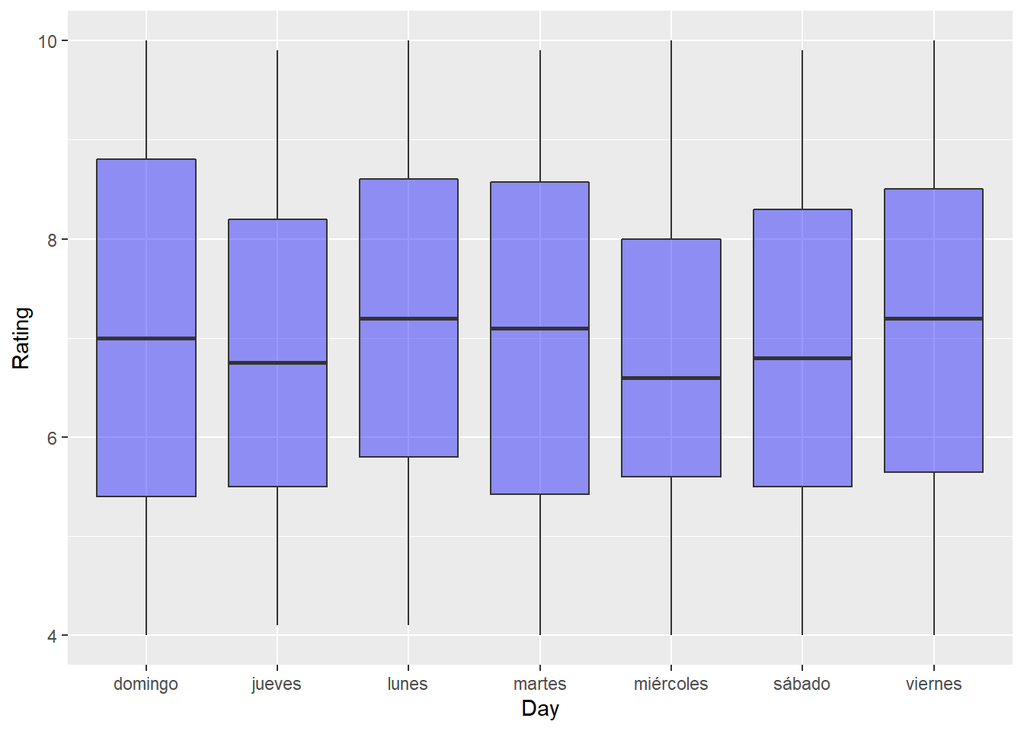

```r
# OBS: Vemos que los precios son similares, pero que van subiendo un poco de Branch en Branch en cuando
# la media. En cambio, en Rating, se ve una clara baja de este en la Branch B.

#6. Boxplot Day vs Rating
ggplot(df) +
  aes(x=Day, y=Rating) +
  geom_boxplot(alpha=0.4, fill="blue") #cambiamos el tipo de gráfico
```

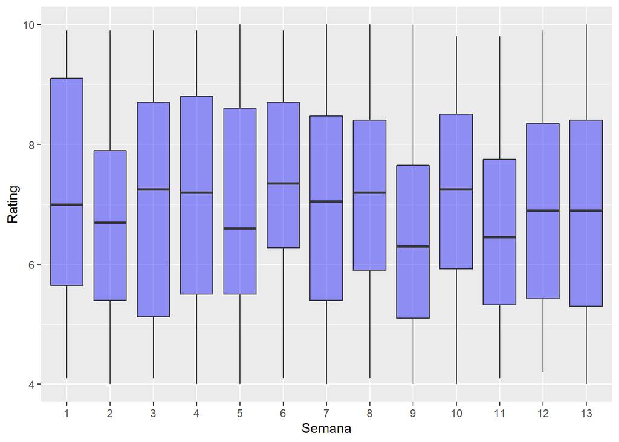

```r
#OBS: se ven ciertos cambios en el rating según el día

#9. Boxplot Semana vs Rating
ggplot(df) +
  aes(x=Semana, y=Rating) +
  geom_boxplot(alpha=0.4, fill="blue") #cambiamos el tipo de gráfico
```

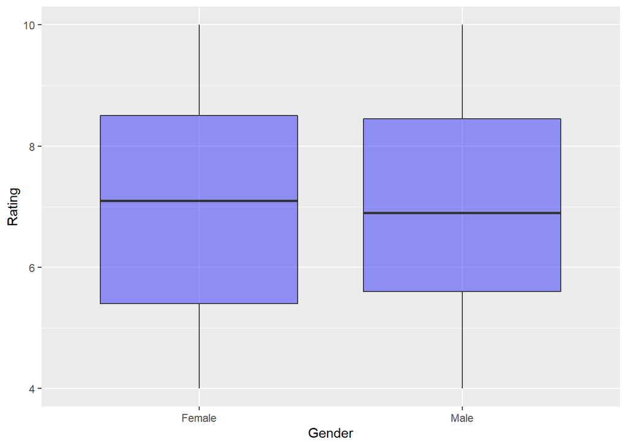

```r
#OBS: se ven ciertos cambios en el rating según la semana

#11. Boxplot Gender vs Rating
ggplot(df) +
  aes(x=Gender, y=Rating) +
  geom_boxplot(alpha=0.4, fill="blue") #cambiamos el tipo de gráfico
```

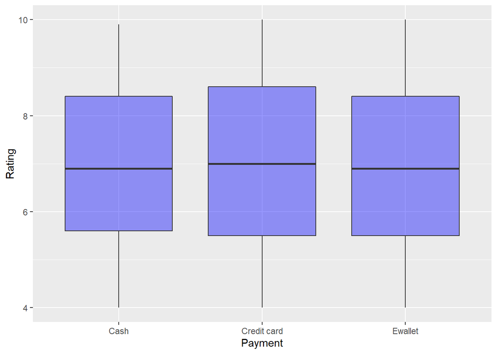

```r
#OBS: no hay cambios notables

#13. Boxplot Payment vs Rating
ggplot(df) +
  aes(x=Payment, y=Rating) +
  geom_boxplot(alpha=0.4, fill="blue") #cambiamos el tipo de gráfico
```

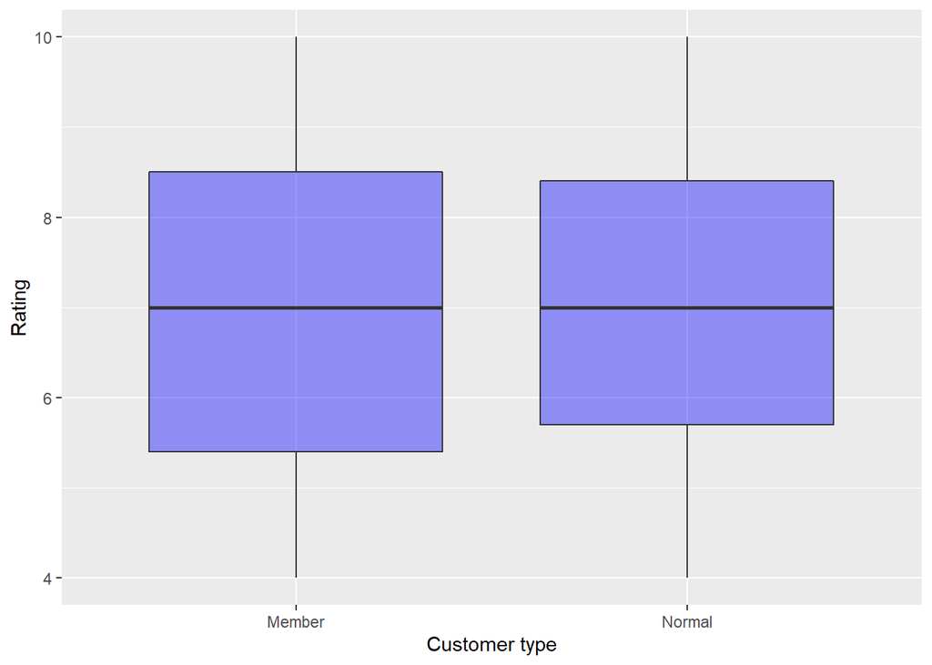

```r
#OBS: pocos cambios

#15. Boxplot Customer type vs Rating
ggplot(df) +
  aes(x=`Customer type`, y=Rating) +
  geom_boxplot(alpha=0.4, fill="blue") #cambiamos el tipo de gráfico
```

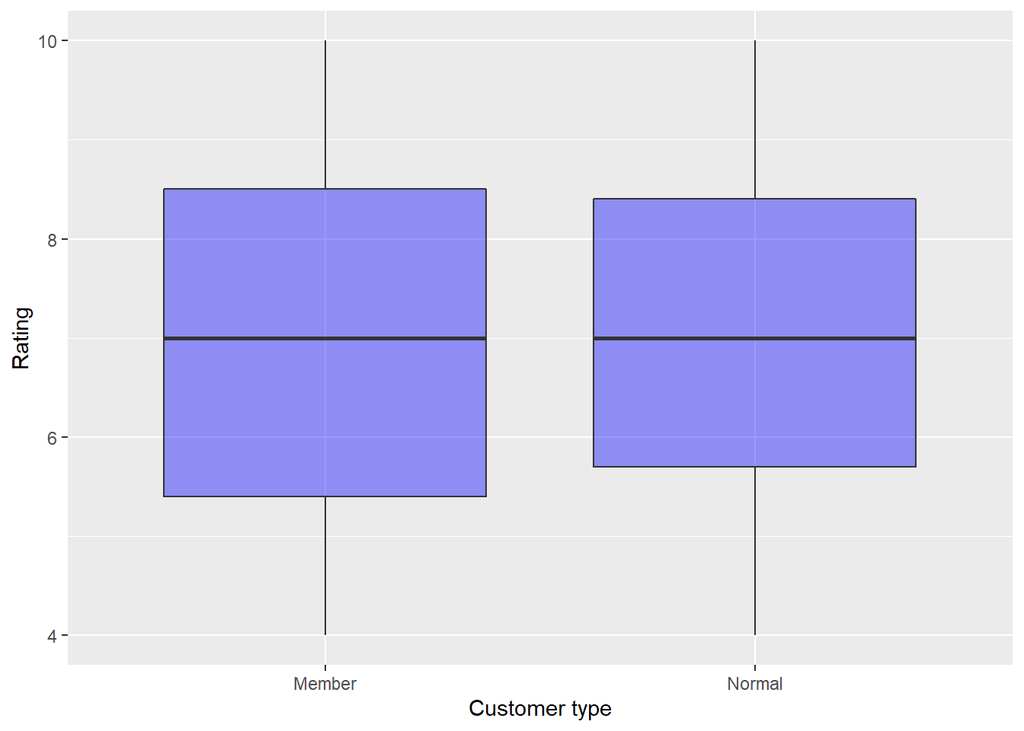

```r
#17. Boxplot Customer type vs Rating
ggplot(df) +
  aes(x=`Customer type`, y=Rating) +
  geom_boxplot(alpha=0.4, fill="blue") #cambiamos el tipo de gráfico
```

Se puede observar que casi ninguna variable categórica parece tener un efecto por sí sola sobre la variable de inerés. Lo único destacable que podemos rescatar es la baja en el `Rating` que parece presentar la `Branch` B en primera instancia.

Ahora se realiza un último análisis con las variables numéricas:

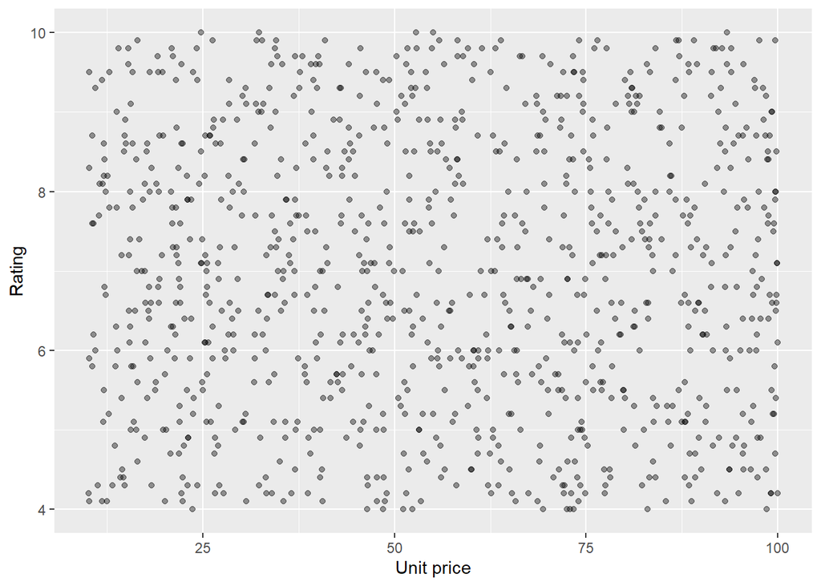

```r
#17.1. Scatter Unir price vs Rating
ggplot(df) +
  aes(x=`Unit price`, y=Rating) +
  geom_point(alpha=0.4, fill="blue") #cambiamos el tipo de gráfico
```

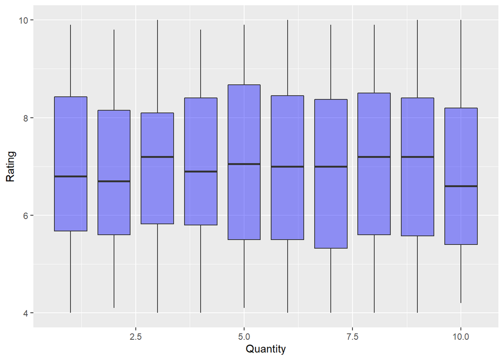

```r
#17.2. Boxplot Quantity type vs Rating
ggplot(df) +
  aes(x=Quantity, y=Rating, group=Quantity) +
  geom_boxplot(alpha=0.4, fill="blue") #cambiamos el tipo de gráfico
```

Claramente se puede evidenciar que no existe relación alguna entre la variable de interés y el precio unitario por sí solo, ya que el scatterplot es prácticamente al azar. En cuanto a la cantidad de productos, tampoco se puede llegar a una conclusión, ya que no hay mayores cambios además de un leve aumento en las cantidades medias-altas, pero podría no ser un efecto.

Para corroborar completamente, se confirma por última vez con una matriz de correlaciones:

```r
df_numeric <- select_if(df, is.numeric)
corr <- cor(df_numeric)
corr
```

```
##                           Unit price    Quantity     Tax 5%      Total
## Unit price               1.000000000  0.01077756  0.6339621  0.6339621
## Quantity                 0.010777564  1.00000000  0.7055102  0.7055102
## Tax 5%                   0.633962089  0.70551019  1.0000000  1.0000000
## Total                    0.633962089  0.70551019  1.0000000  1.0000000
## cogs                     0.633962089  0.70551019  1.0000000  1.0000000
## gross margin percentage           NA          NA         NA         NA
## gross income             0.633962089  0.70551019  1.0000000  1.0000000
## Rating                  -0.008777507 -0.01581490 -0.0364417 -0.0364417
##                               cogs gross margin percentage gross income
## Unit price               0.6339621                      NA    0.6339621
## Quantity                 0.7055102                      NA    0.7055102
## Tax 5%                   1.0000000                      NA    1.0000000
## Total                    1.0000000                      NA    1.0000000
## cogs                     1.0000000                      NA    1.0000000
## gross margin percentage         NA                       1           NA
## gross income             1.0000000                      NA    1.0000000
## Rating                  -0.0364417                      NA   -0.0364417
##                               Rating
## Unit price              -0.008777507
## Quantity                -0.015814905
## Tax 5%                  -0.036441705
## Total                   -0.036441705
## cogs                    -0.036441705
## gross margin percentage           NA
## gross income            -0.036441705
## Rating                   1.000000000
```

```r
corr2 <- rcorr(as.matrix(df_numeric))
corr2
```

```
##                         Unit price Quantity Tax 5% Total  cogs
## Unit price                    1.00     0.01   0.63  0.63  0.63
## Quantity                      0.01     1.00   0.71  0.71  0.71
## Tax 5%                        0.63     0.71   1.00  1.00  1.00
## Total                         0.63     0.71   1.00  1.00  1.00
## cogs                          0.63     0.71   1.00  1.00  1.00
## gross margin percentage        NaN      NaN    NaN   NaN   NaN
## gross income                  0.63     0.71   1.00  1.00  1.00
## Rating                       -0.01    -0.02  -0.04 -0.04 -0.04
##                         gross margin percentage gross income Rating
## Unit price                                  NaN         0.63  -0.01
## Quantity                                    NaN         0.71  -0.02
## Tax 5%                                      NaN         1.00  -0.04
## Total                                       NaN         1.00  -0.04
## cogs                                        NaN         1.00  -0.04
## gross margin percentage                       1          NaN    NaN
## gross income                                NaN         1.00  -0.04
## Rating                                      NaN        -0.04   1.00
##
## n= 1000
##
##
## P
##                         Unit price Quantity Tax 5% Total  cogs
## Unit price                         0.7336   0.0000 0.0000 0.0000
## Quantity                0.7336              0.0000 0.0000 0.0000
## Tax 5%                  0.0000     0.0000          0.0000 0.0000
## Total                   0.0000     0.0000   0.0000        0.0000
## cogs                    0.0000     0.0000   0.0000 0.0000
## gross margin percentage
## gross income            0.0000     0.0000   0.0000 0.0000 0.0000
## Rating                  0.7816     0.6174   0.2496 0.2496 0.2496
##                         gross margin percentage gross income Rating
## Unit price                                      0.0000       0.7816
## Quantity                                        0.0000       0.6174
## Tax 5%                                          0.0000       0.2496
## Total                                           0.0000       0.2496
## cogs                                            0.0000       0.2496
## gross margin percentage
## gross income                                                 0.2496
## Rating                                          0.2496
```

Nuevamente se ve que no existe relación alguna con las variables independientes numéricas de manera separada con respecto a la variable de interés. Las correlaciones son prácticamente 0 (y tampoco son significativas).

##### 3. EDA Tridimensional

A continuación, se analizarán efectos conjuntos (con más de una variable independiente) sobre la variable de interés, tomando distintas combinaciones de la base:

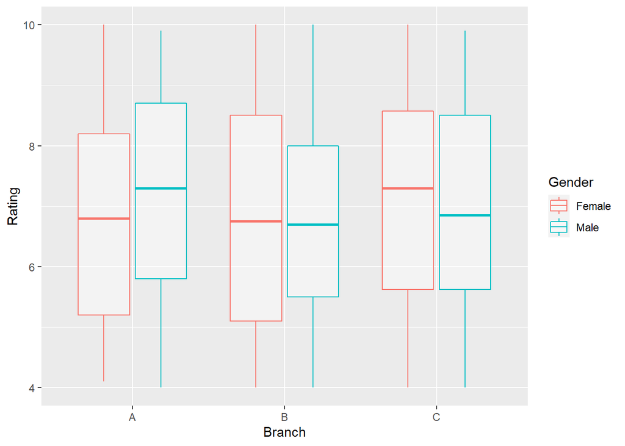

```r
#
# Tridimensionales Categóricas
#

#---------------------------------------------------------------------
# Branch v/s Rating

#18. Boxplot Branch v/s Rating r/ Gender
ggplot(df) +
  aes(x=Branch, y=Rating, col=Gender) +
  geom_boxplot(alpha=0.4, fill='white') #cambiamos el tipo de gráfico
```

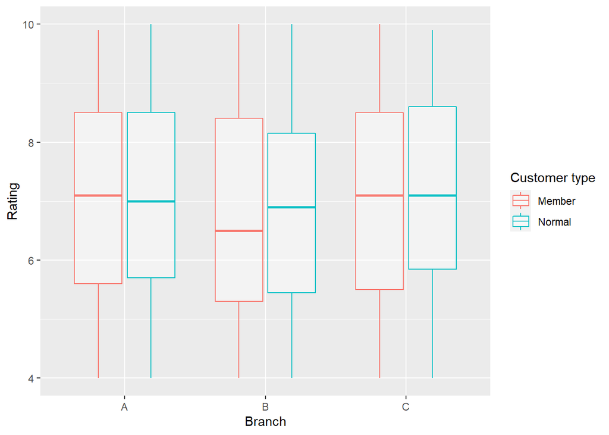

```r
#OBS: hay variaciones entre calificaciones por genero según la tienda

#19. Boxplot Branch v/s Rating r/ `Customer type`
ggplot(df) +
  aes(x=Branch, y=Rating, col=`Customer type`) +
  geom_boxplot(alpha=0.4, fill='white') #cambiamos el tipo de gráfico
```

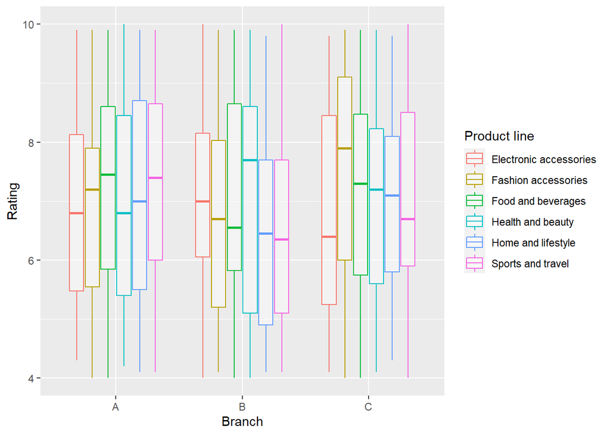

```r
#20. Boxplot Branch v/s Rating r/ `Product Line`
ggplot(df) +
  aes(x=Branch, y=Rating, col=`Product line`) +
  geom_boxplot(alpha=0.4, fill='white') #cambiamos el tipo de gráfico
```

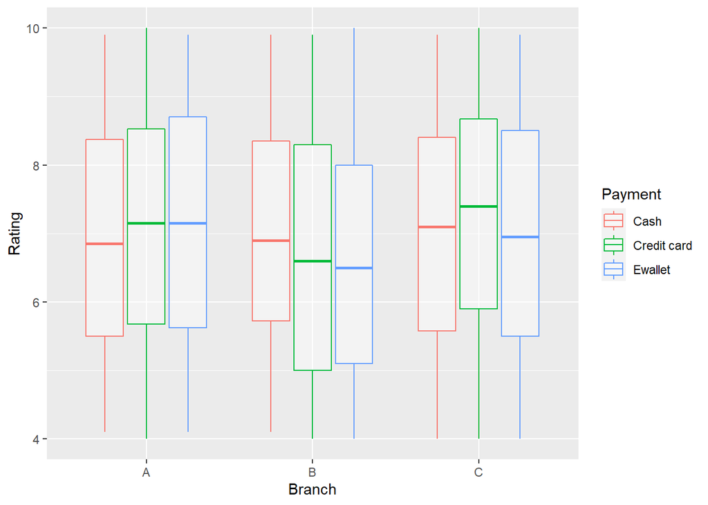

```r
#OBS: hay variaciones entre las calificaciones según el tipo de producto y tienda

#21. Boxplot Branch v/s Rating r/ Payment
ggplot(df) +
  aes(x=Branch, y=Rating, col=Payment) +
  geom_boxplot(alpha=0.4, fill='white') #cambiamos el tipo de gráfico
```

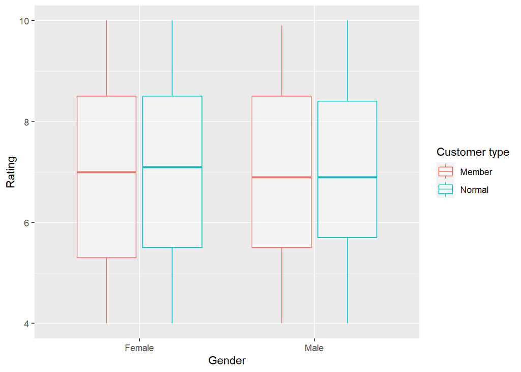

```r
#OBS: hay ciertas variaciones pero no tan importantes

#---------------------------------------------------------------------
# Gender v/s Rating

#22. Boxplot Gender v/s Rating r/ `Customer type`
ggplot(df) +
  aes(x=Gender, y=Rating, col=`Customer type`) +
  geom_boxplot(alpha=0.4, fill='white') #cambiamos el tipo de gráfico
```

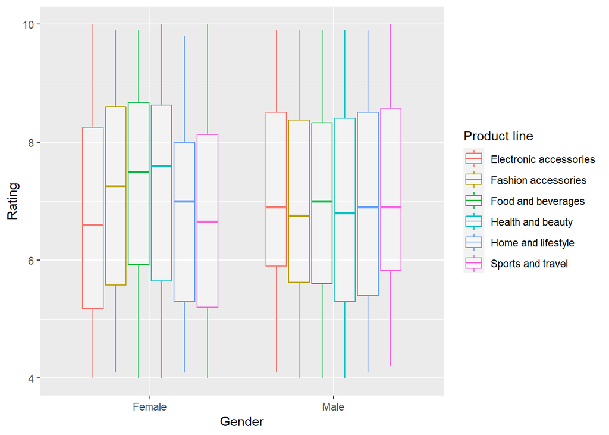

```r
#23. Boxplot Gender v/s Rating r/ `Product Line`
ggplot(df) +
  aes(x=Gender, y=Rating, col=`Product line`) +
  geom_boxplot(alpha=0.4, fill='white') #cambiamos el tipo de gráfico
```

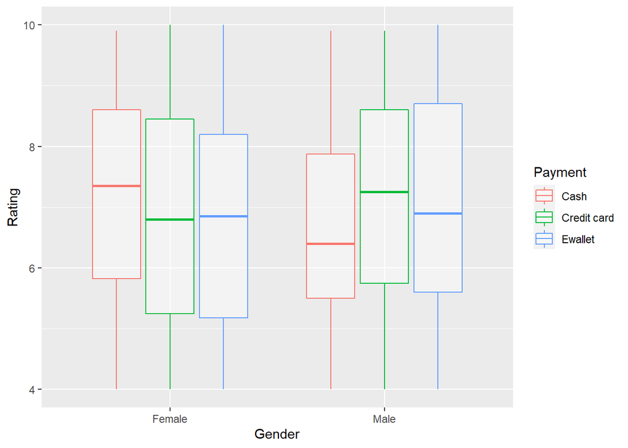

```r
#24. Boxplot Gender v/s Rating r/ Payment
ggplot(df) +
  aes(x=Gender, y=Rating, col=Payment) +
  geom_boxplot(alpha=0.4, fill='white') #cambiamos el tipo de gráfico
```

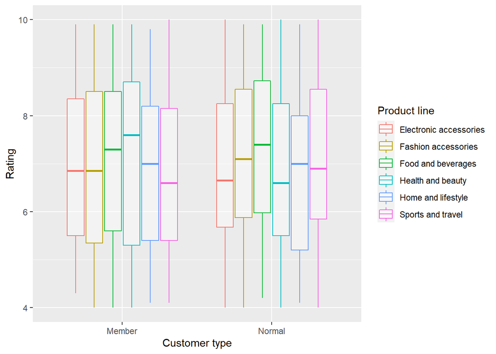

```r
#---------------------------------------------------------------------
# `Customer type` v/s Rating

#25. Boxplot `Customer type` v/s Rating r/ `Product Line`
ggplot(df) +
  aes(x=`Customer type`, y=Rating, col=`Product line`) +
  geom_boxplot(alpha=0.4, fill='white') #cambiamos el tipo de gráfico
```

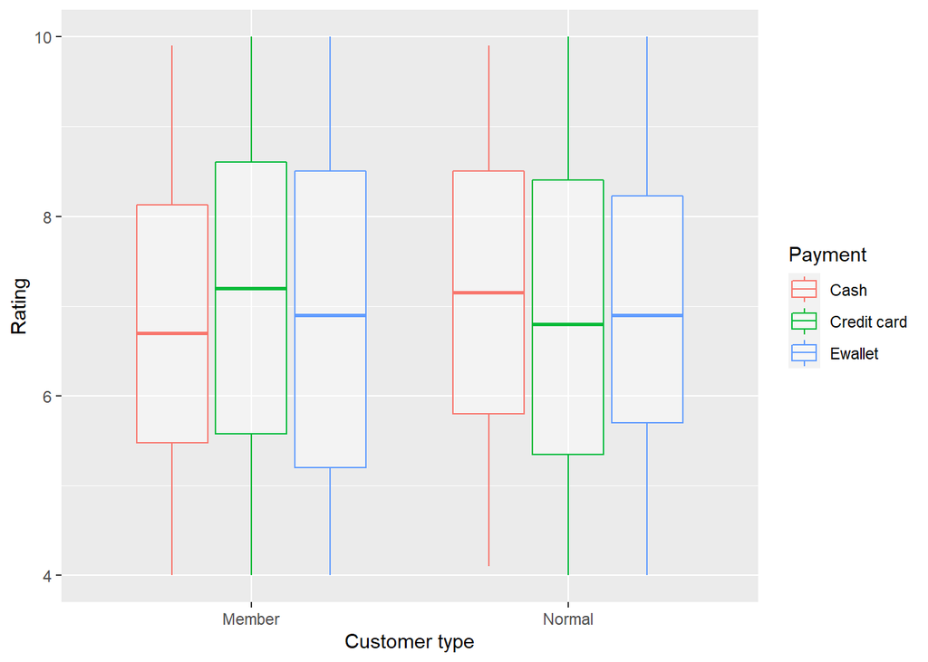

```r
#26. Boxplot `Customer type` v/s Rating r/ Payment
ggplot(df) +
  aes(x=`Customer type`, y=Rating, col=Payment) +
  geom_boxplot(alpha=0.4, fill='white') #cambiamos el tipo de gráfico
```

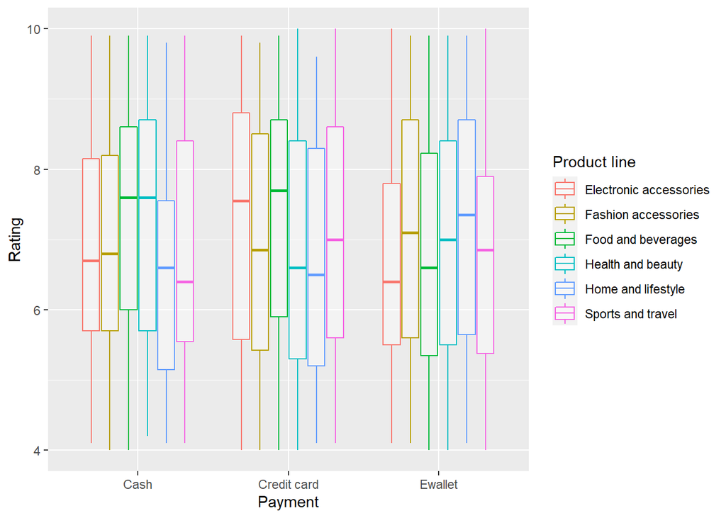

```r
#---------------------------------------------------------------------
# `Product Line` v/s Rating

#27. Boxplot `Product line`  v/s Rating r/ Payment
ggplot(df) +
  aes(x=Payment, y=Rating, col=`Product line`) +
  geom_boxplot(alpha=0.4, fill='white') #cambiamos el tipo de gráfico
```

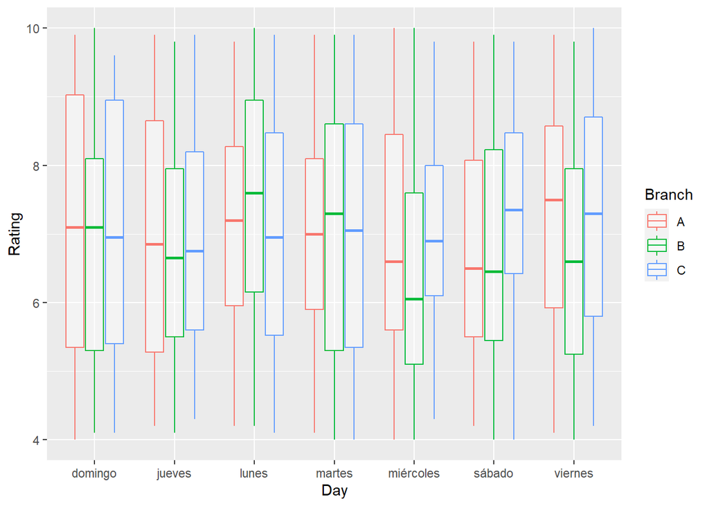

```r
#---------------------------------------------------------------------

# Tiempo incluído

#---------------------------------------------------------------------

# Tiempo agregado

#28. Boxplot Branch v/s Rating r/ Day
ggplot(df) +
  aes(x=Day, y=Rating, col=Branch) +
  geom_boxplot(alpha=0.4, fill='white') #cambiamos el tipo de gráfico
```

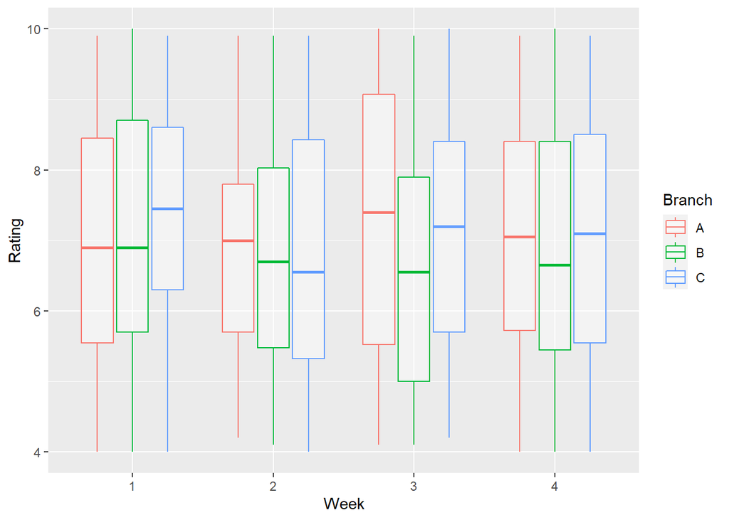

```r
#29. Boxplot Branch v/s Rating r/ Week
ggplot(df) +
  aes(x=Week, y=Rating, col=Branch) +
  geom_boxplot(alpha=0.4, fill='white') #cambiamos el tipo de gráfico
```

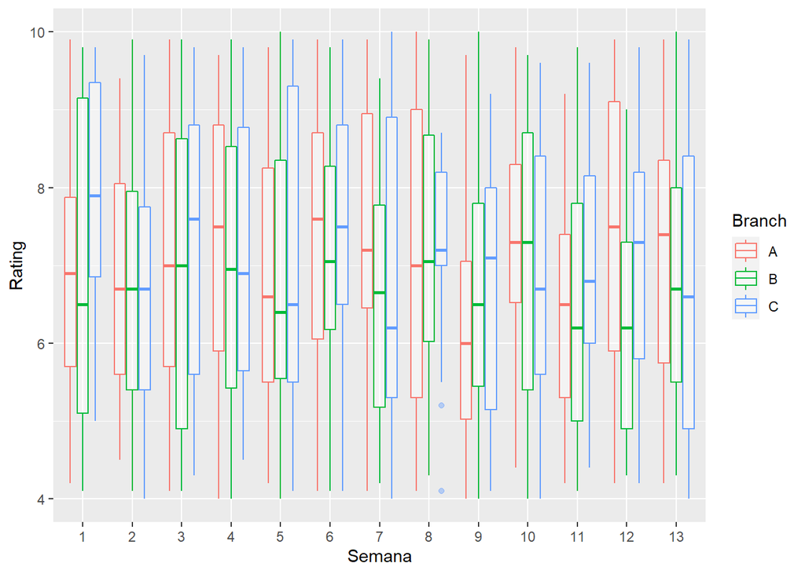

```r
# Tiempo contínuo

#30. Boxplot Branch v/s Rating r/ Week
ggplot(df) +
  aes(x=Semana, y=Rating, col=Branch) +
  geom_boxplot(alpha=0.4, fill='white') #cambiamos el tipo de gráfico
```

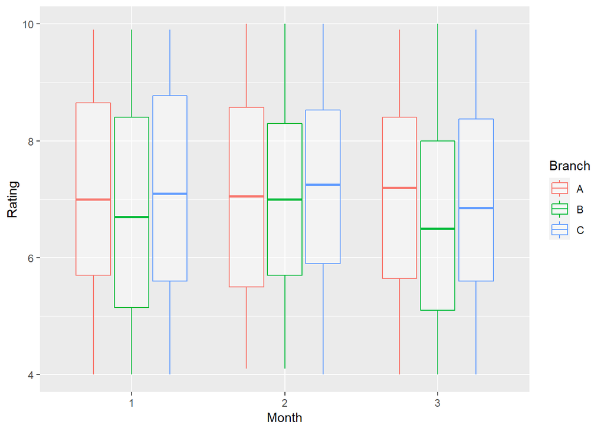

```r
#31. Boxplot Branch v/s Rating r/ Week
ggplot(df) +
  aes(x=Month, y=Rating, col=Branch) +
  geom_boxplot(alpha=0.4, fill='white') #cambiamos el tipo de gráfico
```

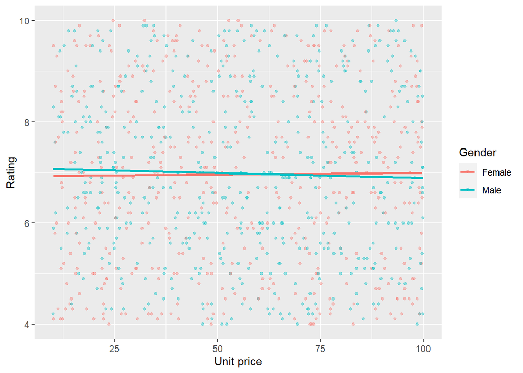

```r
#---------------------------------------------------------------------

# Numéricas

#---------------------------------------------------------------------

#32. Scatterplot Unit Price v/s Rating r/ Gender
ggplot(df) +
  aes(x=`Unit price`, y=Rating, col=Gender)+ #Se agrega una dimensión de colores "col".
  geom_point(size=1, alpha=0.4) +
  geom_smooth(se=FALSE, method="lm")
```

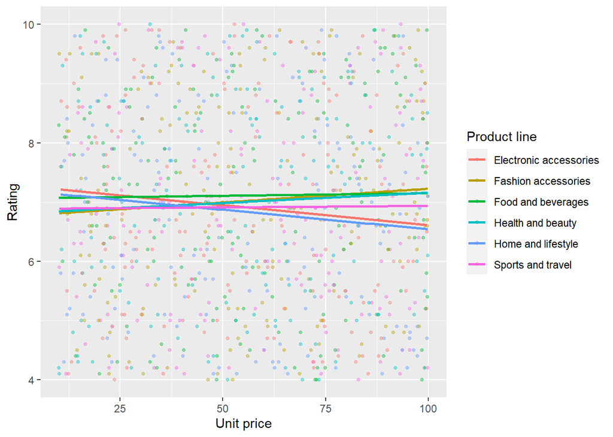

```r
#33. Scatterplot Unit Price v/s Rating r/ Gender
ggplot(df) +
    aes(x=`Unit price`, y=Rating, col=`Product line`)+ #Se agrega una dimensión de colores "col".
    geom_point(size=1, alpha=0.4) +
  geom_smooth(se=FALSE, method="lm")
```

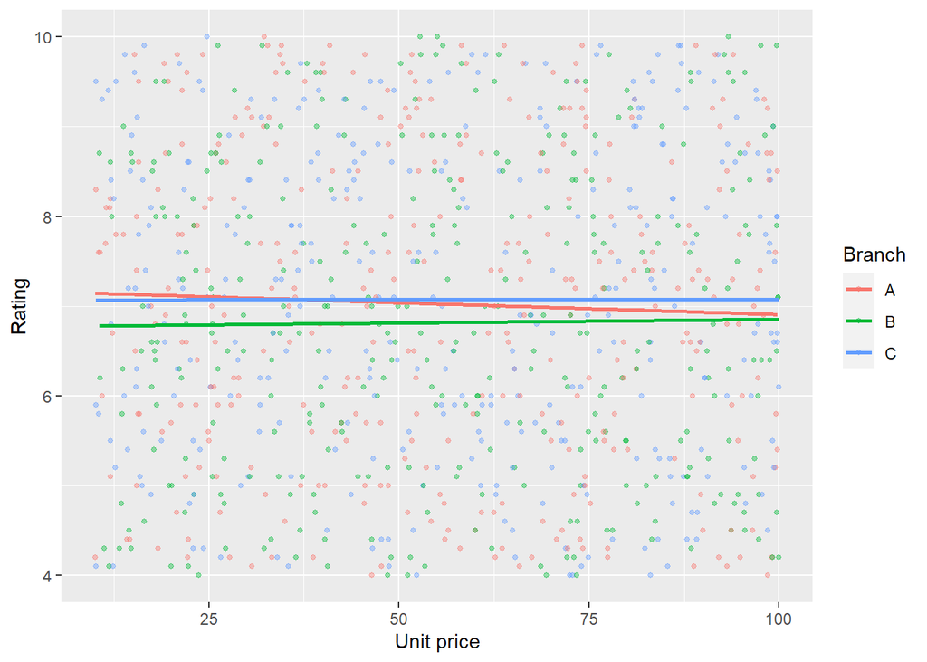

```r
#33. Scatterplot Unit Price v/s Rating r/ Gender
ggplot(df) +
  aes(x=`Unit price`, y=Rating, col=Branch)+ #Se agrega una dimensión de colores "col".
  geom_point(size=1, alpha=0.4) +
  geom_smooth(se=FALSE, method="lm")
```

De este análisis, ya se pueden observar ciertas interacciones entre variables que pudiesen explicar el Rating, como lo es en el caso del género y la línea de los productos, donde se puede ver que el género femenino presenta mayor variación de Rating entre líneas, mientras que el género masculino parace mantenerse constante entre ellas. En cuanto al tiempo, también se ven cambios en durante periodos, pero no podemos decir que haya efecto de momento.